# Limpieza y análisis de datos del Titanic

Autores: Saúl Santomé Rúa y Víctor Elías Afonso Rodríguez

Mayo 2021

```r
# Cargamos los paquetes R que vamos a usar
library(ggplot2)
library(dplyr)
library(kableExtra)
# Cargamos el fichero de datos
titanicData <- read.csv('titanicData.csv',stringsAsFactors = FALSE)
filas=dim(titanicData)[1]
columnas=dim(titanicData)[2]
```

# 1. Descripción del dataset. ¿Por qué es importante y qué pregunta/problema pretende responder?

Este *dataset* es interesante porque permite analizar los diferentes perfiles que pudieron acceder al gran barco del momento y además da la posibilidad de localizar que variables permitieron que algunos pasajeros sobrevivieran o no. Consideramos que es un análisis relevante porque conocer los factores que separó a los pasajeros de la vida o muerte se pueden identificar, esto nos lleva a entender mejor como era la sociedad de aquella época.  
Vamos a visualizar la estructura del conjunto de datos.

```
## 'data.frame':    891 obs. of  12 variables:
##  $ PassengerId: int  1 2 3 4 5 6 7 8 9 10 ...
##  $ Survived   : int  0 1 1 1 0 0 0 0 1 1 ...
##  $ Pclass     : int  3 1 3 1 3 3 1 3 3 2 ...
##  $ Name       : chr  "Braund, Mr. Owen Harris" "Cumings, Mrs. John Bradley (Florence Briggs Thayer)" "Heikkinen, Miss. Laina" "Futrelle, Mrs. Jacques Heath (Lily May Peel)" ...
##  $ Sex        : chr  "male" "female" "female" "female" ...
##  $ Age        : num  22 38 26 35 35 NA 54 2 27 14 ...
##  $ SibSp      : int  1 1 0 1 0 0 0 3 0 1 ...
##  $ Parch      : int  0 0 0 0 0 0 0 1 2 0 ...
##  $ Ticket     : chr  "A/5 21171" "PC 17599" "STON/O2. 3101282" "113803" ...
##  $ Fare       : num  7.25 71.28 7.92 53.1 8.05 ...
##  $ Cabin      : chr  "" "C85" "" "C123" ...
##  $ Embarked   : chr  "S" "C" "S" "S" ...
```

Este juego de datos esta compuesto por **891 observaciones y por 12 variables**. Los datos se encuentran en inglés.

Las **variables** son:

```r
names(titanicData)
```

```
##  [1] "PassengerId" "Survived"    "Pclass"      "Name"        "Sex"
##  [6] "Age"         "SibSp"       "Parch"       "Ticket"      "Fare"
## [11] "Cabin"       "Embarked"
```

- **PassengerId**: Es un número que corresponde con el código de cada pasajero.
- **Survived**: Indica si el pasajero sobrevivio o no. Los supervivientes se indica con un “1” y los no supervivientes con un “0”.
- **Pclass**: Indica la clase en la que se encuentra el pasajero.
- **Name**: Es el nombre.
- **Sex**: Indica si es masculino o femenino.
- **Age**: Corresponde con la edad.
- **SibSp**: Es el número de esposas/hermanos que viajan con el pasajero.
- **Parch**: Es el número de padres/niños que viajan junto al pasajero.
- **Ticket**: Número de ticket.
- **Fare**: Precio que ha pagado.
- **Cabin**: Número de cabina.
- **Embarked**: Puerto de embarque.

Vamos a dividir estas variables en cuantitativas y cualitativas según lo ha leido RStudio.

Las **variables cualitativas** son las siguientes:

Variables cualitativas, tipos interpretados

|  | x |
| --- | --- |
| Name | character |
| Sex | character |
| Ticket | character |
| Cabin | character |
| Embarked | character |

Las **variables cuantitativas** son:

```r
idQuantitative<-which(names=="PassengerID"|names=="Survived"|names=="Pclass"|names=="Age"|names=="Sibsp"|names=="Parch"|names=="Fare")
kable( sapply(titanicData[idQuantitative],class),caption="Variables cualitativas, tipos interpretados")
```

|  | x |
| --- | --- |
| Survived | integer |
| Pclass | integer |
| Age | numeric |
| Parch | integer |
| Fare | numeric |

Vamos a ver **datos estadísticos** de cada variable cuantitativa para entender mejor cada una:

```r
titanicData<-titanicData[,-c(12)]
titanicData<-titanicData[,-c(11)]
titanicData<-titanicData[,-c(9)]
titanicData<-titanicData[,-c(5)]
titanicData<-titanicData[,-c(4)]
summary(titanicData)
```

```
##   PassengerId       Survived          Pclass           Age
##  Min.   :  1.0   Min.   :0.0000   Min.   :1.000   Min.   : 0.42
##  1st Qu.:223.5   1st Qu.:0.0000   1st Qu.:2.000   1st Qu.:20.12
##  Median :446.0   Median :0.0000   Median :3.000   Median :28.00
##  Mean   :446.0   Mean   :0.3838   Mean   :2.309   Mean   :29.70
##  3rd Qu.:668.5   3rd Qu.:1.0000   3rd Qu.:3.000   3rd Qu.:38.00
##  Max.   :891.0   Max.   :1.0000   Max.   :3.000   Max.   :80.00
##                                                   NA's   :177
##      SibSp           Parch             Fare
##  Min.   :0.000   Min.   :0.0000   Min.   :  0.00
##  1st Qu.:0.000   1st Qu.:0.0000   1st Qu.:  7.91
##  Median :0.000   Median :0.0000   Median : 14.45
##  Mean   :0.523   Mean   :0.3816   Mean   : 32.20
##  3rd Qu.:1.000   3rd Qu.:0.0000   3rd Qu.: 31.00
##  Max.   :8.000   Max.   :6.0000   Max.   :512.33
##
```

```r
titanicData <- read.csv('titanicData.csv',stringsAsFactors = FALSE)
```

Gracias a este resumen podemos tener una visión del conjunto de los datos. Podemos determinar:  
- **PassegengerID**: Funciona como el número de identificación de cada pasajero. Lo que significa que cada pasajero tiene un número de identificación, este número de identificación es una variable prescidinble ya que el valor que puede aportar es un valor en base a como asignaron cada número a cada pasajero, con lo cual no enriquece el análisis.  
- **Survived**: Tiene un comportamiento binario.  
- **Age**: Nos indica que hay anomalias ya que el valor mínimo es inferior a 1.  
- **Parch**: Observamos que el valor oscila entre 0 y 6.  
- **Fare**: Muestra que hay pasajeros que ha entrado gratis y la mayor cuantía que se ha pagado.

Una vez que conocemos mejor las variables vamos a visualizar los valores que toma cada **variable cualitativa**:

**Name**

```r
table(titanicData$Name)
```

[output not shown]

[output cut: 1728 more lines]

[output not shown]

Verificamos que no hay valores vacíos.

**Sex**

```r
table(titanicData$Sex)
```

```
##
## female   male
##    314    577
```

Esta variable no tiene observaciones sin valor.

```r
577/891*100
```

```
## [1] 64.7587
```

Casi el 65% de los pasageros son de género masculino.

**Ticket**

```r
table(titanicData$Ticket)
```

[output not shown]

[output cut: 328 more lines]

Observamos que no tiene valores vacíos y que no todos los valores son únicos.

**Cabin**

```r
table(titanicData$Cabin)
```

```
##
##                             A10             A14             A16             A19
##             687               1               1               1               1
##             A20             A23             A24             A26             A31
##               1               1               1               1               1
##             A32             A34             A36              A5              A6
##               1               1               1               1               1
##              A7            B101            B102             B18             B19
##               1               1               1               2               1
##             B20             B22             B28              B3             B30
##               2               2               2               1               1
##             B35             B37             B38             B39              B4
##               2               1               1               1               1
##             B41             B42             B49              B5             B50
##               1               1               2               2               1
##     B51 B53 B55 B57 B59 B63 B66         B58 B60             B69             B71
##               2               2               2               1               1
##             B73             B77             B78             B79             B80
##               1               2               1               1               1
##         B82 B84             B86             B94         B96 B98            C101
##               1               1               1               4               1
##            C103            C104            C106            C110            C111
##               1               1               1               1               1
##            C118            C123            C124            C125            C126
##               1               2               2               2               2
##            C128            C148              C2         C22 C26     C23 C25 C27
##               1               1               2               3               4
##             C30             C32             C45             C46             C47
##               1               1               1               1               1
##             C49             C50             C52             C54         C62 C64
##               1               1               2               1               1
##             C65             C68              C7             C70             C78
##               2               2               1               1               2
##             C82             C83             C85             C86             C87
##               1               2               1               1               1
##             C90             C91             C92             C93             C95
##               1               1               2               2               1
##             C99               D         D10 D12             D11             D15
##               1               3               1               1               1
##             D17             D19             D20             D21             D26
##               2               1               2               1               2
##             D28             D30             D33             D35             D36
##               1               1               2               2               2
##             D37             D45             D46             D47             D48
##               1               1               1               1               1
##             D49             D50             D56              D6              D7
##               1               1               1               1               1
##              D9             E10            E101             E12            E121
##               1               1               3               1               2
##             E17             E24             E25             E31             E33
##               1               2               2               1               2
##             E34             E36             E38             E40             E44
##               1               1               1               1               2
##             E46             E49             E50             E58             E63
##               1               1               1               1               1
##             E67             E68             E77              E8           F E69
##               2               1               1               2               1
##           F G63           F G73              F2             F33             F38
##               1               2               3               3               1
##              F4              G6               T
##               2               4               1
```

Observamos que tiene 687 observaciones sin valor.

**Embarked**

```r
table(titanicData$Embarked)
```

```
##
##       C   Q   S
##   2 168  77 644
```

Obtenemos que esta variable puede encontrarse de 3 maneras diferentes y tiene 2 observaciones sin valor.

Una vez que conocemos mejor las variables vamos a visualizar los valores que toma cada **variable cuantitativa**:

**Survived**

```r
table(titanicData$Survived)
```

```
##
##   0   1
## 549 342
```

```r
342/549*100
```

```
## [1] 62.29508
```

El 62% de los pasajeros fallecieron.

**Pclass**

```r
table(titanicData$Pclass)
```

```
##
##   1   2   3
## 216 184 491
```

Solo hay 3 clases diferentes y la menos numerosa es la segunda.

**Age**

```r
table(titanicData$Age)
```

```
##
## 0.42 0.67 0.75 0.83 0.92    1    2    3    4    5    6    7    8    9   10   11
##    1    1    2    2    1    7   10    6   10    4    3    3    4    8    2    4
##   12   13   14 14.5   15   16   17   18   19   20 20.5   21   22   23 23.5   24
##    1    2    6    1    5   17   13   26   25   15    1   24   27   15    1   30
## 24.5   25   26   27   28 28.5   29   30 30.5   31   32 32.5   33   34 34.5   35
##    1   23   18   18   25    2   20   25    2   17   18    2   15   15    1   18
##   36 36.5   37   38   39   40 40.5   41   42   43   44   45 45.5   46   47   48
##   22    1    6   11   14   13    2    6   13    5    9   12    2    3    9    9
##   49   50   51   52   53   54   55 55.5   56   57   58   59   60   61   62   63
##    6   10    7    6    1    8    2    1    4    2    5    2    4    3    4    2
##   64   65   66   70 70.5   71   74   80
##    2    3    1    2    1    2    1    1
```

Observamos que hay decimales. Lo que indica que nos puede resultar interesante agrupar para que los valores de las observaciones en valores enteros.

**SibSp**

```r
table(titanicData$SibSp)
```

```
##
##   0   1   2   3   4   5   8
## 608 209  28  16  18   5   7
```

**Parch**

```r
table(titanicData$Parch)
```

```
##
##   0   1   2   3   4   5   6
## 678 118  80   5   4   5   1
```

Lo más habitual es que no tuvieran niños.

**Fare**

```r
table(titanicData$Fare)
```

```
##
##        0   4.0125        5   6.2375   6.4375     6.45   6.4958     6.75
##       15        1        1        1        1        1        2        2
##   6.8583     6.95    6.975   7.0458     7.05   7.0542    7.125   7.1417
##        1        1        2        1        7        2        4        1
##    7.225   7.2292     7.25   7.3125   7.4958   7.5208     7.55   7.6292
##       12       15       13        1        3        1        4        1
##     7.65    7.725   7.7292   7.7333   7.7375   7.7417     7.75    7.775
##        4        1        1        4        2        1       34       16
##   7.7875   7.7958      7.8   7.8292   7.8542    7.875   7.8792   7.8875
##        1        6        1        2       13        1        4        1
##   7.8958    7.925   8.0292     8.05   8.1125   8.1375   8.1583      8.3
##       38       18        1       43        1        1        1        1
##   8.3625   8.4042   8.4333   8.4583   8.5167   8.6542   8.6625   8.6833
##        1        1        1        1        1        1       13        1
##   8.7125     8.85        9   9.2167    9.225     9.35    9.475   9.4833
##        1        1        2        1        2        2        1        1
##      9.5   9.5875    9.825   9.8375   9.8417   9.8458  10.1708  10.4625
##        9        2        2        1        1        1        1        2
##     10.5  10.5167  11.1333  11.2417     11.5       12   12.275  12.2875
##       24        1        3        2        4        1        1        1
##    12.35   12.475   12.525    12.65   12.875       13  13.4167     13.5
##        3        4        1        1        1       42        1        4
##  13.7917  13.8583  13.8625       14  14.1083     14.4  14.4542  14.4583
##        1        1        1        1        1        2        7        3
##     14.5       15  15.0458    15.05     15.1  15.2458     15.5    15.55
##        7        1        1        1        1        5        8        1
##  15.7417    15.75    15.85     15.9       16     16.1     16.7     17.4
##        2        1        4        2        1        9        2        1
##     17.8       18    18.75  18.7875  19.2583     19.5  19.9667  20.2125
##        2        3        3        2        4        2        2        2
##    20.25   20.525   20.575       21   21.075  21.6792   22.025  22.3583
##        2        3        2        6        4        1        1        2
##   22.525       23    23.25    23.45       24    24.15  25.4667  25.5875
##        1        4        2        2        2        8        4        1
##   25.925  25.9292       26    26.25  26.2833  26.2875  26.3875    26.55
##        1        2       31        6        1        3        1       15
##       27  27.7208    27.75     27.9     28.5  28.7125       29   29.125
##        2        5        4        6        1        1        2        5
##     29.7       30  30.0708     30.5  30.6958       31   31.275  31.3875
```

[output cut: 8 more lines]

```
##        1        1        2        7        3        5        2        1
##     55.9  56.4958  56.9292       57  57.9792     59.4   61.175  61.3792
##        2        7        2        2        2        1        1        1
##  61.9792  63.3583       65     66.6     69.3    69.55       71  71.2833
##        1        1        2        2        2        7        2        1
##     73.5    75.25  76.2917  76.7292  77.2875  77.9583  78.2667    78.85
##        5        1        1        3        2        3        2        2
##     79.2    79.65       80  81.8583  82.1708  83.1583   83.475     86.5
##        4        3        2        1        2        3        2        3
##  89.1042       90  91.0792     93.5  106.425    108.9 110.8833  113.275
##        2        4        2        2        2        2        4        3
##      120   133.65    134.5 135.6333 146.5208   151.55 153.4625 164.8667
##        4        2        2        3        2        4        3        2
## 211.3375    211.5 221.7792  227.525 247.5208  262.375      263 512.3292
##        3        1        1        4        2        2        4        3
```

No hay valores vacíos.

# 2. Integración y selección de los datos de interés a analizar

Hay variables que no vamos a necesitar:  
- PassengerId  
- Name  
- Ticket - Fare - Cabin  
- Embarked

```r
titanicData<-titanicData[,-c(12)]
titanicData<-titanicData[,-c(11)]
titanicData<-titanicData[,-c(10)]
titanicData<-titanicData[,-c(9)]
titanicData<-titanicData[,-c(4)]
titanicData<-titanicData[,-c(1)]
```

Esto significa que nos quedamos solo con 6 variables.

```r
summary(titanicData)
```

```
##     Survived          Pclass          Sex                 Age
##  Min.   :0.0000   Min.   :1.000   Length:891         Min.   : 0.42
##  1st Qu.:0.0000   1st Qu.:2.000   Class :character   1st Qu.:20.12
##  Median :0.0000   Median :3.000   Mode  :character   Median :28.00
##  Mean   :0.3838   Mean   :2.309                      Mean   :29.70
##  3rd Qu.:1.0000   3rd Qu.:3.000                      3rd Qu.:38.00
##  Max.   :1.0000   Max.   :3.000                      Max.   :80.00
##                                                      NA's   :177
##      SibSp           Parch
##  Min.   :0.000   Min.   :0.0000
##  1st Qu.:0.000   1st Qu.:0.0000
##  Median :0.000   Median :0.0000
##  Mean   :0.523   Mean   :0.3816
##  3rd Qu.:1.000   3rd Qu.:0.0000
##  Max.   :8.000   Max.   :6.0000
##
```

# 3. Limpieza de los datos

# 3.1 ¿Los datos contienen ceros o elementos vacíos? ¿Cómo gestionarías cada uno de estos casos?

Como hemos identificado anteriormente la única variable que tiene valores nulos es *Age*.

```r
colSums(is.na(titanicData))
```

```
## Survived   Pclass      Sex      Age    SibSp    Parch
##        0        0        0      177        0        0
```

```r
colSums(titanicData=="")
```

```
## Survived   Pclass      Sex      Age    SibSp    Parch
##        0        0        0       NA        0        0
```

```
Hay un total de 177 pasajeros que no tienen edad.
```

```r
177/891*100
```

```
## [1] 19.86532
```

```r
# Ponemos la media a los valores vacíos de la variable "Age"
women_df <-titanicData[titanicData$Sex == "female",]
women_mean_age <- mean(titanicData$Age, na.rm= TRUE)
print(women_mean_age)
```

```
## [1] 29.69912
```

```r
men_df <-titanicData[titanicData$Sex == "male",]
men_mean_age <- mean(men_df$Age, na.rm= TRUE)
print(men_mean_age)
```

```
## [1] 30.72664
```

```r
titanicData$Age[is.na(titanicData$Age) & titanicData$Sex=="female" ] <- women_mean_age
titanicData$Age[is.na(titanicData$Age) & titanicData$Sex=="male" ] <- men_mean_age
```

# 3.2. Identificación y tratamiento de valores extremos.

Vamos a analizar los valores extremos, la mejor manera de identificarlos es a través de los boxplot:

```r
library(reshape)
```

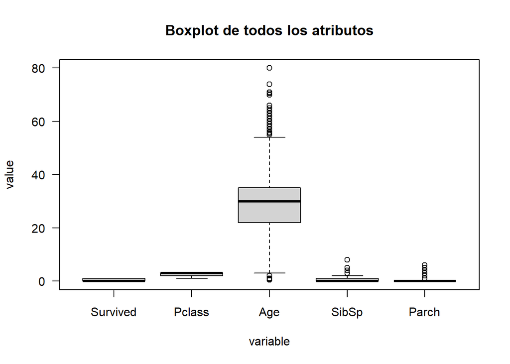

```r
boxplot(data=melt(titanicData), value~variable, las=1, main="Boxplot de todos los atributos")
```

```r
summary(titanicData)
```

```
##     Survived          Pclass          Sex                 Age
##  Min.   :0.0000   Min.   :1.000   Length:891         Min.   : 0.42
##  1st Qu.:0.0000   1st Qu.:2.000   Class :character   1st Qu.:22.00
##  Median :0.0000   Median :3.000   Mode  :character   Median :30.00
##  Mean   :0.3838   Mean   :2.309                      Mean   :29.84
##  3rd Qu.:1.0000   3rd Qu.:3.000                      3rd Qu.:35.00
##  Max.   :1.0000   Max.   :3.000                      Max.   :80.00
##      SibSp           Parch
##  Min.   :0.000   Min.   :0.0000
##  1st Qu.:0.000   1st Qu.:0.0000
##  Median :0.000   Median :0.0000
##  Mean   :0.523   Mean   :0.3816
##  3rd Qu.:1.000   3rd Qu.:0.0000
##  Max.   :8.000   Max.   :6.0000
```

Observamos que hay 3 variables con **valores extremos**. Estas variables son: - Age  
- SibSp  
- Parch

Podemos plantearnos que tanto *SibSp* como *Parch* son factores, por lo que realmente no son **valores atípicos**, por lo que realmente el enfoque tenemos que ponerlo en *Age*. *Age* tiene los valores correctos ya que corresponde con edades lógicas, por lo que procedemos a dejarla correctamente.

# 4. Análisis de los datos

## 4.1 Selección de los grupos de datos que quiere analizar/comparar (planificación de los análisis a aplicar)

Antes de tomar una decisión de los grupos a comparar vamos a mirar la correlación, para ello vamos a transformar la variable *sex* a tipo integer.

```r
table(titanicData$Sex)
```

```
##
## female   male
##    314    577
```

```r
titanicData$Sex <- factor(titanicData$Sex, levels=c("female","male"), labels=c(1, 2))
titanicData$Sex<-as.integer(titanicData$Sex)
table(titanicData$Sex)
```

```
##
##   1   2
## 314 577
```

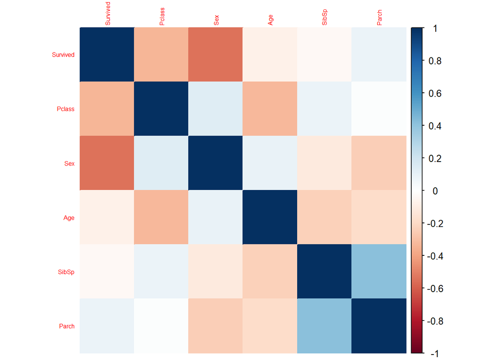

```r
library(corrplot)
corrplot(cor(titanicData), method="color", tl.cex = 0.5)
```

Gracias a la correlación podemos mirar si hay cierta relación en los comportamientos de una variable respecto a las demas. La figura anterior nos indica que es interesante comparar: - Survived con Pclass - Survived con Sex - Age con Pclass - Parch con SibSp

## 4.2 Comprobación de la normalidad y homogeneidad de la varianza

### 4.2.1 Comprobación de la normalidad

Empleamos el test de Shapiro-Wilk para comprobar si se encuentra distribuida de manera normal.  
Generamos un contraste de Hipótesis.  
$H_{0}$: Nuestra hipótesis nula es que los datos provienen de una distribución normal.  
$H_{1}$: Nuestra hipótesis alternativa es que los datos no provienen de una distribución normal.

```r
titanicData$Age<-as.numeric(titanicData$Age)
shapiro.test(titanicData$Age)
```

```
##
##  Shapiro-Wilk normality test
##
## data:  titanicData$Age
## W = 0.9625, p-value = 2.392e-14
```

```r
shapiro.test(titanicData$SibSp)
```

```
##
##  Shapiro-Wilk normality test
##
## data:  titanicData$SibSp
## W = 0.51297, p-value < 2.2e-16
```

```r
shapiro.test(titanicData$Parch)
```

```
##
##  Shapiro-Wilk normality test
##
## data:  titanicData$Parch
## W = 0.53281, p-value < 2.2e-16
```

Hemos aplicado el test en las variables que tienen más de 3 tipos de valores diferentes. El test nos indica que p-value es inferior al 5%, por lo que podemos **afirmar la hipotesis alternativa**, esto significa que los datos no se deistribuyen de una manera normal.

### 4.2.2 Homogeneidad de la varianza

Para comprobar la homogeneidad de varianzas entre poblaciones empleamos el test de Fligner-Killeen.

```r
fligner.test(Survived ~ Pclass, titanicData)
```

```
##
##  Fligner-Killeen test of homogeneity of variances
##
## data:  Survived by Pclass
## Fligner-Killeen:med chi-squared = 35.766, df = 2, p-value = 1.712e-08
```

p-value es inferior al 5% lo que nos indica que la varianza de ambas muestras son diferentes, lo que significa que rechazamos la hipotesis nula y **nos quedamos con la hipótesis alternativa**.

**Survived con Sex**  
Vamos a comprobar si la varianza de hombres y mujeres es la misma dentro de la variable Survived.  
$H_{0}$: Nuestra hipótesis nula es que la varianza entre hombres y mujeres es la misma en Survived.  
$H_{1}$: Nuestra hipótesis alternativa es que la varianza entre hombres y mujeres es diferente en Survived.

```r
fligner.test(Survived ~ Sex, titanicData)
```

```
##
##  Fligner-Killeen test of homogeneity of variances
##
## data:  Survived by Sex
## Fligner-Killeen:med chi-squared = 5.7729, df = 1, p-value = 0.01627
```

p-value es inferior al 5% lo que nos indica que la varianza de ambas muestras son diferentes, lo que significa que rechazamos la hipotesis nula y **nos quedamos con la hipótesis alternativa**.

**Age con Pclass**  
Vamos a comprobar si la varianza de clases es la misma dentro de la variable Age.  
$H_{0}$: Nuestra hipótesis nula es que la varianza entre clases es la misma en Age.  
$H_{1}$: Nuestra hipótesis alternativa es que la varianza entre clases es diferente en Age.

```r
fligner.test(Age ~ Pclass, titanicData)
```

```
##
##  Fligner-Killeen test of homogeneity of variances
##
## data:  Age by Pclass
## Fligner-Killeen:med chi-squared = 28.794, df = 2, p-value = 5.59e-07
```

p-value es inferior al 5% lo que nos indica que la varianza de ambas muestras son diferentes, lo que significa que rechazamos la hipotesis nula y **nos quedamos con la hipótesis alternativa**.

**Parch con SibSp** Vamos a comprobar si la varianza de número de esposas/hermanos es la misma dentro de la variable Parch.  
$H_{0}$: Nuestra hipótesis nula es que la varianza entre número de esposas/hermanos es la misma en Parch.  
$H_{1}$: Nuestra hipótesis alternativa es que la varianza entre número de esposas/hermanos es diferente en Parch.

```r
fligner.test(Parch ~ SibSp, titanicData)
```

```
##
##  Fligner-Killeen test of homogeneity of variances
##
## data:  Parch by SibSp
## Fligner-Killeen:med chi-squared = 106.38, df = 6, p-value < 2.2e-16
```

p-value es inferior al 5% lo que nos indica que la varianza de ambas muestras son diferentes, lo que significa que rechazamos la hipotesis nula y **nos quedamos con la hipótesis alternativa**.

## 4.3 Aplicación de pruebas estadísticas para comparar los grupos de datos. En función de los datos y el objetivo del estudio, aplicar pruebas de contraste de hipótesis, correlaciones, regresiones, etc. Aplicar al menos tres métodos de análisis diferentes.

### 4.3.1 Regresiones

**Survived con Pclass**

```r
regsurvpclass<-lm(Survived~Pclass, titanicData)

summary(regsurvpclass)
```

```
##
## Call:
## lm(formula = Survived ~ Pclass, data = titanicData)
##
## Residuals:
##     Min      1Q  Median      3Q     Max
## -0.6416 -0.2476 -0.2476  0.3584  0.7524
##
## Coefficients:
##             Estimate Std. Error t value Pr(>|t|)
## (Intercept)  0.83863    0.04510   18.60   <2e-16 ***
## Pclass      -0.19700    0.01837  -10.72   <2e-16 ***
## ---
## Signif. codes:  0 '***' 0.001 '**' 0.01 '*' 0.05 '.' 0.1 ' ' 1
##
## Residual standard error: 0.4581 on 889 degrees of freedom
## Multiple R-squared:  0.1146, Adjusted R-squared:  0.1136
## F-statistic:   115 on 1 and 889 DF,  p-value: < 2.2e-16
```

```r
regsexsurv<-lm(Survived~Sex, titanicData)

summary(regsexsurv)
```

```
##
## Call:
## lm(formula = Survived ~ Sex, data = titanicData)
##
## Residuals:
##     Min      1Q  Median      3Q     Max
## -0.7420 -0.1889 -0.1889  0.2580  0.8111
##
## Coefficients:
##             Estimate Std. Error t value Pr(>|t|)
## (Intercept)  1.29517    0.04917   26.34   <2e-16 ***
## Sex         -0.55313    0.02866  -19.30   <2e-16 ***
## ---
## Signif. codes:  0 '***' 0.001 '**' 0.01 '*' 0.05 '.' 0.1 ' ' 1
##
## Residual standard error: 0.4087 on 889 degrees of freedom
## Multiple R-squared:  0.2952, Adjusted R-squared:  0.2944
## F-statistic: 372.4 on 1 and 889 DF,  p-value: < 2.2e-16
```

**Multiple R-squared** es 0.2952 esto significa que no podemos emplear la variable *Sex* para predecir *Survived*. Hay que tener en cuenta que lo ideal es que sea lo más cercano a 1 y en este caso es mucho más cercano a 0.  
**P-value** es inferior a 2.2e-16, esto es muy buena señal, los estudios suelen realizarse con un nivel de significación del 5% y en este caso es muy inferior, por lo que podemos estar contento porque es una muy buena regresión.

**Age con Pclass**

```r
regagepclass<-lm(Age~Pclass, titanicData)
summary(regagepclass)
```

```
##
## Call:
## lm(formula = Age ~ Pclass, data = titanicData)
##
## Residuals:
##     Min      1Q  Median      3Q     Max
## -35.590  -6.811   0.585   4.585  47.681
##
## Coefficients:
##             Estimate Std. Error t value Pr(>|t|)
## (Intercept)   41.606      1.210   34.37   <2e-16 ***
## Pclass        -5.095      0.493  -10.34   <2e-16 ***
## ---
## Signif. codes:  0 '***' 0.001 '**' 0.01 '*' 0.05 '.' 0.1 ' ' 1
##
## Residual standard error: 12.3 on 889 degrees of freedom
## Multiple R-squared:  0.1073, Adjusted R-squared:  0.1063
## F-statistic: 106.8 on 1 and 889 DF,  p-value: < 2.2e-16
```

**Parch con SibSp**

```r
regparchsibsp<-lm(Parch~SibSp, titanicData)
summary(regparchsibsp)
```

```
##
## Call:
## lm(formula = Parch ~ SibSp, data = titanicData)
##
## Residuals:
##    Min     1Q Median     3Q    Max
## -1.133 -0.223 -0.223 -0.223  5.474
##
## Coefficients:
##             Estimate Std. Error t value Pr(>|t|)
## (Intercept)  0.22300    0.02721   8.195  8.7e-16 ***
## SibSp        0.30323    0.02231  13.594  < 2e-16 ***
## ---
## Signif. codes:  0 '***' 0.001 '**' 0.01 '*' 0.05 '.' 0.1 ' ' 1
##
## Residual standard error: 0.7338 on 889 degrees of freedom
## Multiple R-squared:  0.1721, Adjusted R-squared:  0.1712
## F-statistic: 184.8 on 1 and 889 DF,  p-value: < 2.2e-16
```

### 4.3.2 Correlaciones

```r
cor(titanicData)
```

```
##             Survived      Pclass         Sex         Age       SibSp
## Survived  1.00000000 -0.33848104 -0.54335138 -0.07554602 -0.03532250
## Pclass   -0.33848104  1.00000000  0.13190049 -0.32752776  0.08308136
## Sex      -0.54335138  0.13190049  1.00000000  0.09223687 -0.11463081
## Age      -0.07554602 -0.32752776  0.09223687  1.00000000 -0.23381356
## SibSp    -0.03532250  0.08308136 -0.11463081 -0.23381356  1.00000000
## Parch     0.08162941  0.01844267 -0.24548896 -0.18290288  0.41483770
##                Parch
## Survived  0.08162941
## Pclass    0.01844267
## Sex      -0.24548896
## Age      -0.18290288
## SibSp     0.41483770
## Parch     1.00000000
```

Vamos a destacar las correlaciones superiores al +-0,30: Survived-Pclass, Survived-Sex, Age-Pclass y SibSp-Parch. Recordemos que el signo significa que ambas crecen o decrecen a la vez y si el simbolo es negativo significa que cuando una crece la otra decrece o a la inversa.

# 5. Representación de los resultados a partir de tablas y gráficas

**Regresión Survived con Pclass**

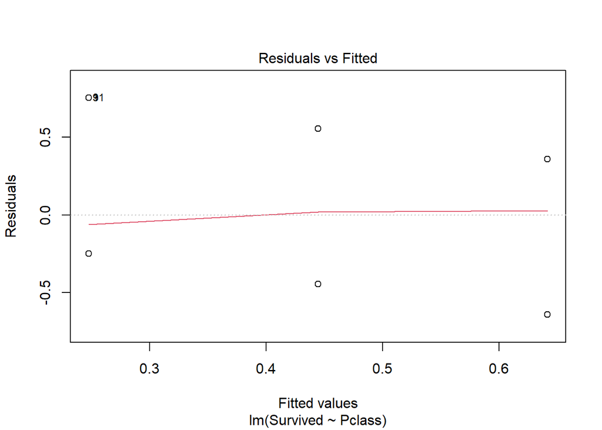

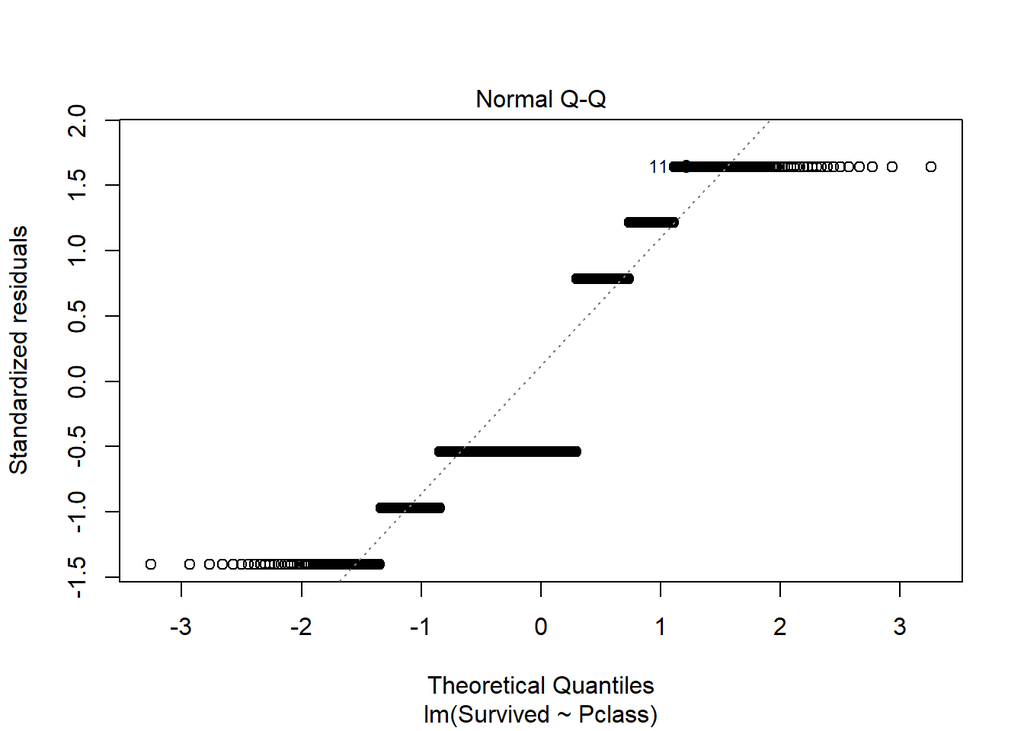

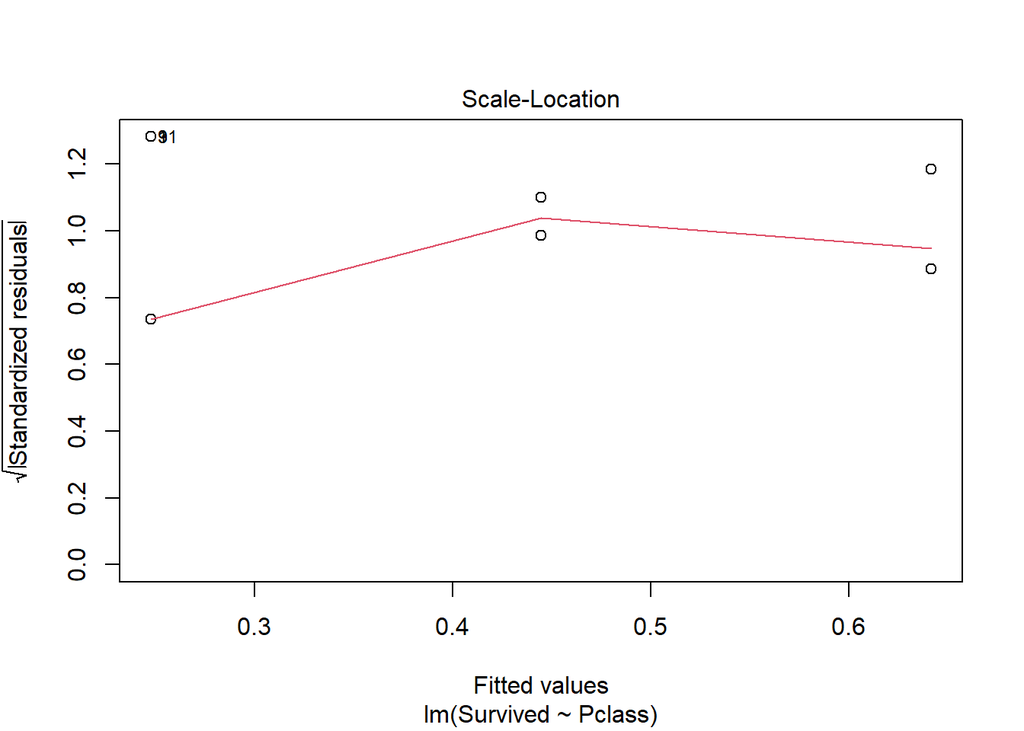

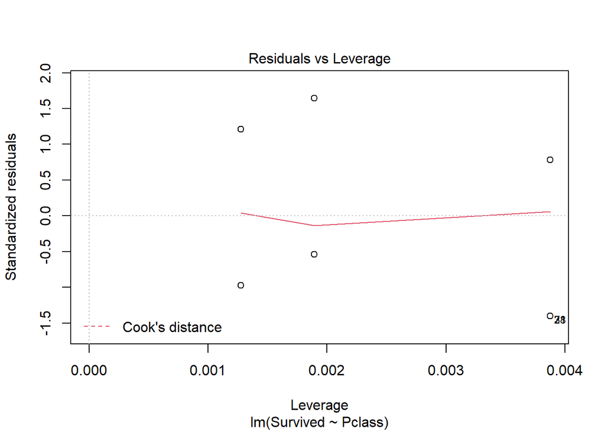

```r
plot(regsurvpclass)
```

**Regresión Sex con Survived**

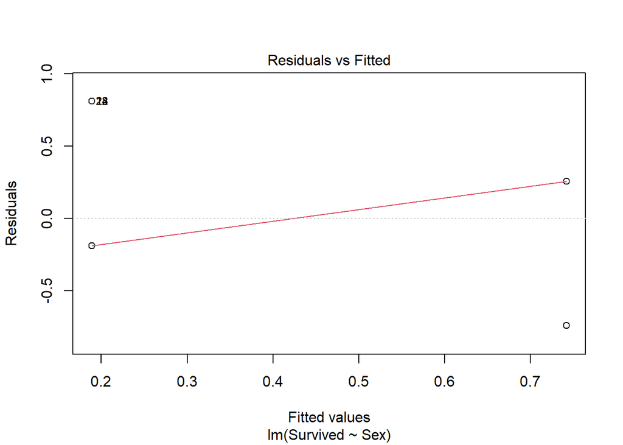

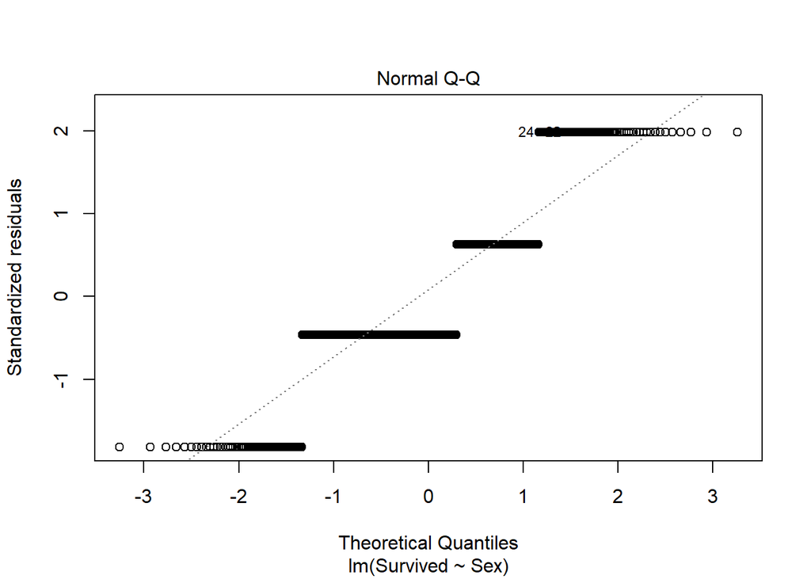

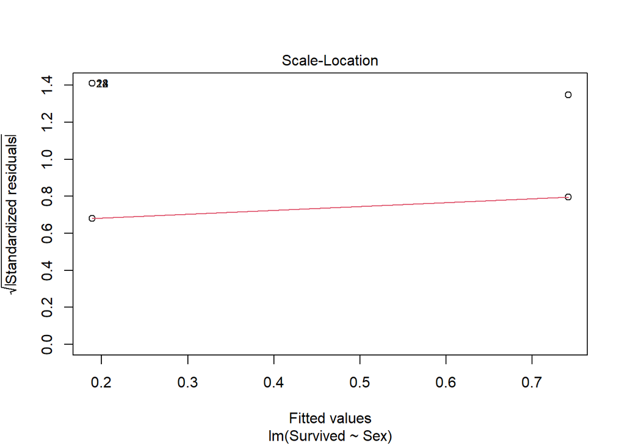

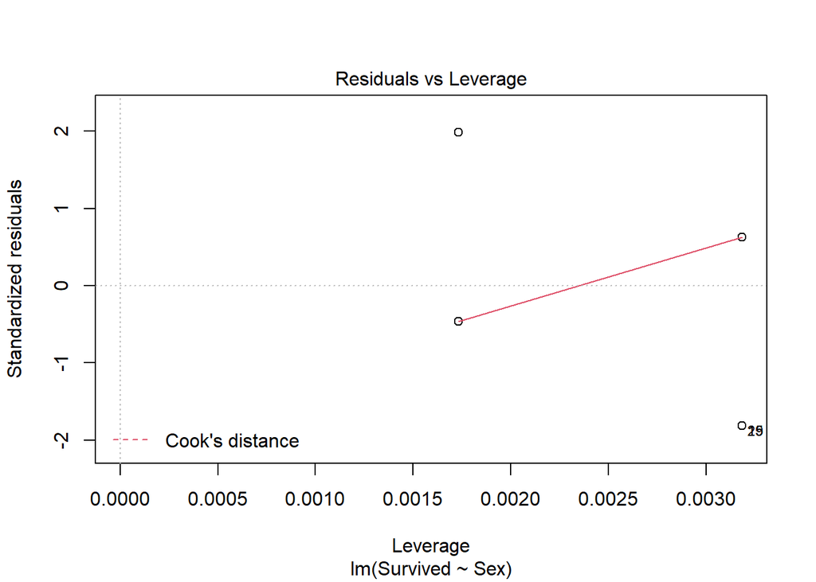

```r
plot(regsexsurv)
```

**Regresión Age con Pclass**

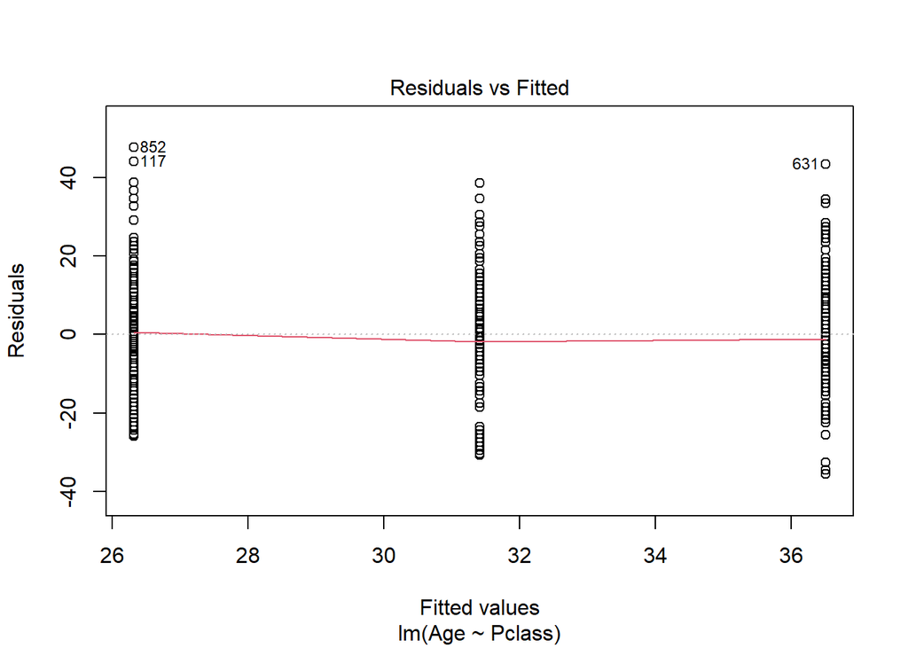

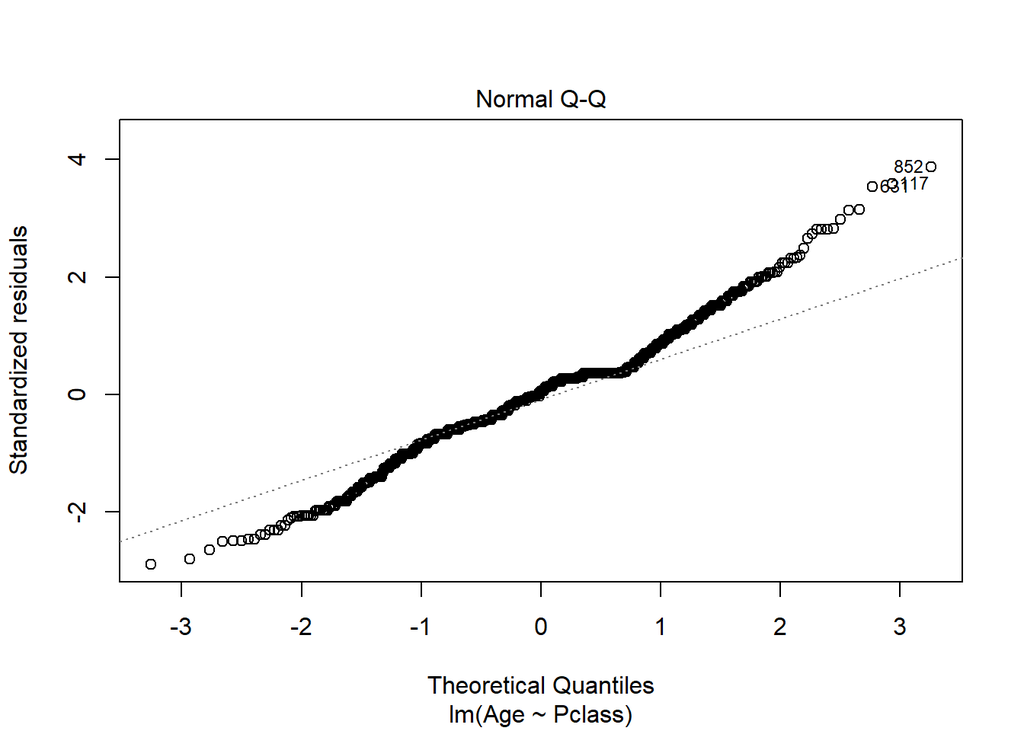

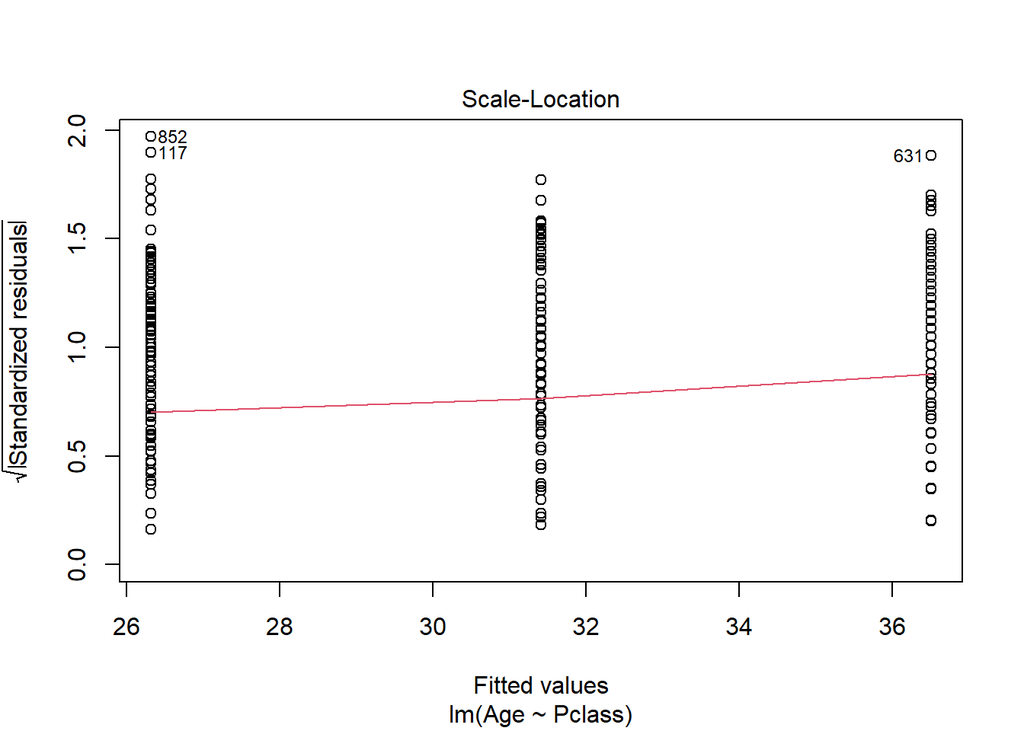

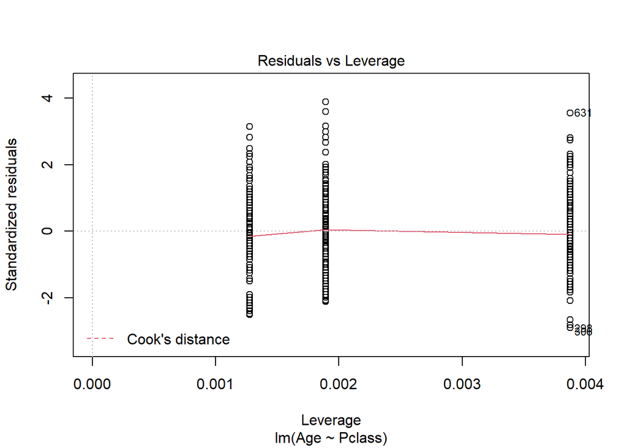

```r
plot(regagepclass)
```

**Regresión Parch con SibSp**

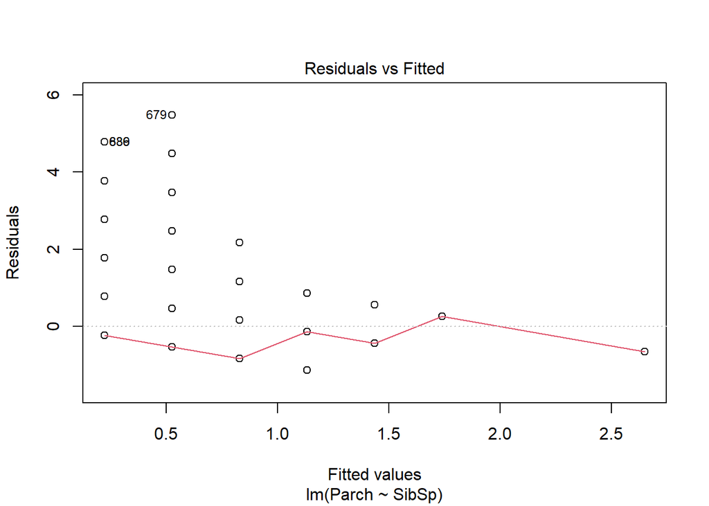

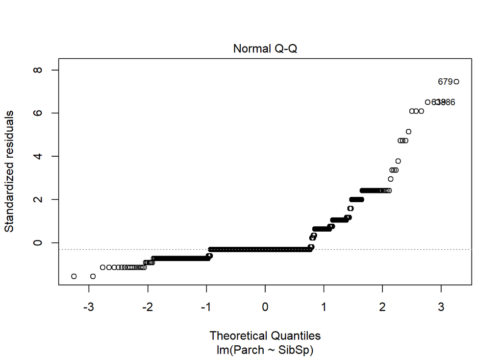

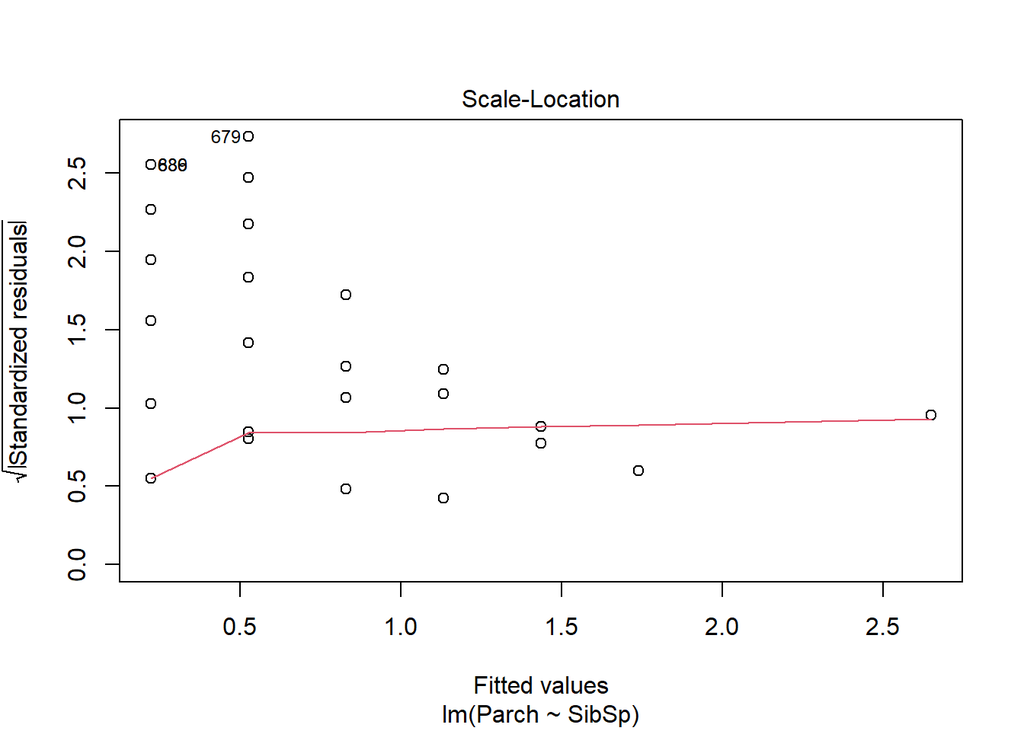

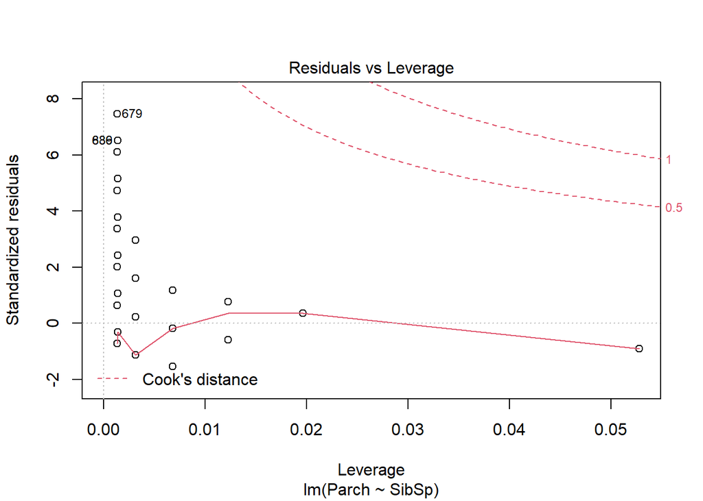

```r
plot(regparchsibsp)
```

**Representación mediante tabla de las correlaciones entre las diferentes variables**

```r
cor(titanicData)
```

```
##             Survived      Pclass         Sex         Age       SibSp
## Survived  1.00000000 -0.33848104 -0.54335138 -0.07554602 -0.03532250
## Pclass   -0.33848104  1.00000000  0.13190049 -0.32752776  0.08308136
## Sex      -0.54335138  0.13190049  1.00000000  0.09223687 -0.11463081
## Age      -0.07554602 -0.32752776  0.09223687  1.00000000 -0.23381356
## SibSp    -0.03532250  0.08308136 -0.11463081 -0.23381356  1.00000000
## Parch     0.08162941  0.01844267 -0.24548896 -0.18290288  0.41483770
##                Parch
## Survived  0.08162941
## Pclass    0.01844267
## Sex      -0.24548896
## Age      -0.18290288
## SibSp     0.41483770
## Parch     1.00000000
```

# 6. Resolución del problema. A partir de los resultados obtenidos, ¿cuáles son las conclusiones? ¿Los resultados permiten responder al problema?

Las conclusiones que podemos sacar del estudio son las siguientes:  
- Los **valores extremos** encontrados son lógicos.  
- Según el test de **Shapiro-Wilk** concluimos que los datos de las variables estudiadas **no muestran una distribución normal**.  
- Mediante el test de **Fligner-Kill** afirmamos que en los datos de las variables estudiadas **no hay homogeneidad de la varianza**.  
- Basándonos en la **regresión lineal** determinamos que el conjunto de variables estudiadas no pueden emplearse para predecir las demás.  
- La prueba de **regresión lineal** indica que el conjunto de variables estudiadas tienen un nivel de significación inferior al 5% lo que significa tienen un nivel de confianza superior al 95%.  
- Hay una **correlación** superior al +-0,30 en: *Survived-Pclass*, *Survived-Sex*, *Age-Pclass* y *SibSp-Parch*.  
Estos resultados permiten responder al problema porque ayuda a comprender que variables estan relacionadas entre ellas y especialmente con la variable *Survived*.